# SISBID3: Classification

R version

## 1 The Stock Market Data

We load the packages needed for this lab and explore the `Smarket` data set and visualize the correlations among variables. Note that if you try `cor(Smarket)` you will get an error stating `Error in cor(Smarket) : 'x' must be numeric`. This is because `Direction` is a *categorical* variable, hence, not *numeric*. So, below, we remove this variable before looking at correlations.

```r
library(ISLR)
library(MASS)
library(glmnet)
library(class)
library(e1071)
library(ROCR)

names(Smarket)
```

```
## [1] "Year"      "Lag1"      "Lag2"      "Lag3"      "Lag4"      "Lag5"
## [7] "Volume"    "Today"     "Direction"
```

```r
dim(Smarket)
```

```
## [1] 1250    9
```

```r
summary(Smarket)
```

```
##       Year           Lag1                Lag2                Lag3
##  Min.   :2001   Min.   :-4.922000   Min.   :-4.922000   Min.   :-4.922000
##  1st Qu.:2002   1st Qu.:-0.639500   1st Qu.:-0.639500   1st Qu.:-0.640000
##  Median :2003   Median : 0.039000   Median : 0.039000   Median : 0.038500
##  Mean   :2003   Mean   : 0.003834   Mean   : 0.003919   Mean   : 0.001716
##  3rd Qu.:2004   3rd Qu.: 0.596750   3rd Qu.: 0.596750   3rd Qu.: 0.596750
##  Max.   :2005   Max.   : 5.733000   Max.   : 5.733000   Max.   : 5.733000
##       Lag4                Lag5              Volume           Today
##  Min.   :-4.922000   Min.   :-4.92200   Min.   :0.3561   Min.   :-4.922000
##  1st Qu.:-0.640000   1st Qu.:-0.64000   1st Qu.:1.2574   1st Qu.:-0.639500
##  Median : 0.038500   Median : 0.03850   Median :1.4229   Median : 0.038500
##  Mean   : 0.001636   Mean   : 0.00561   Mean   :1.4783   Mean   : 0.003138
##  3rd Qu.: 0.596750   3rd Qu.: 0.59700   3rd Qu.:1.6417   3rd Qu.: 0.596750
##  Max.   : 5.733000   Max.   : 5.73300   Max.   :3.1525   Max.   : 5.733000
##  Direction
##  Down:602
##  Up  :648
##
##
##
##
```

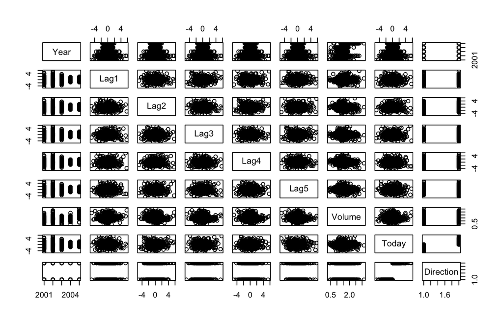

```r
pairs(Smarket)
```

```r
cor(Smarket[,-9])
```

```
##              Year         Lag1         Lag2         Lag3         Lag4
## Year   1.00000000  0.029699649  0.030596422  0.033194581  0.035688718
## Lag1   0.02969965  1.000000000 -0.026294328 -0.010803402 -0.002985911
## Lag2   0.03059642 -0.026294328  1.000000000 -0.025896670 -0.010853533
## Lag3   0.03319458 -0.010803402 -0.025896670  1.000000000 -0.024051036
## Lag4   0.03568872 -0.002985911 -0.010853533 -0.024051036  1.000000000
## Lag5   0.02978799 -0.005674606 -0.003557949 -0.018808338 -0.027083641
## Volume 0.53900647  0.040909908 -0.043383215 -0.041823686 -0.048414246
## Today  0.03009523 -0.026155045 -0.010250033 -0.002447647 -0.006899527
##                Lag5      Volume        Today
## Year    0.029787995  0.53900647  0.030095229
## Lag1   -0.005674606  0.04090991 -0.026155045
## Lag2   -0.003557949 -0.04338321 -0.010250033
## Lag3   -0.018808338 -0.04182369 -0.002447647
## Lag4   -0.027083641 -0.04841425 -0.006899527
## Lag5    1.000000000 -0.02200231 -0.034860083
## Volume -0.022002315  1.00000000  0.014591823
## Today  -0.034860083  0.01459182  1.000000000
```

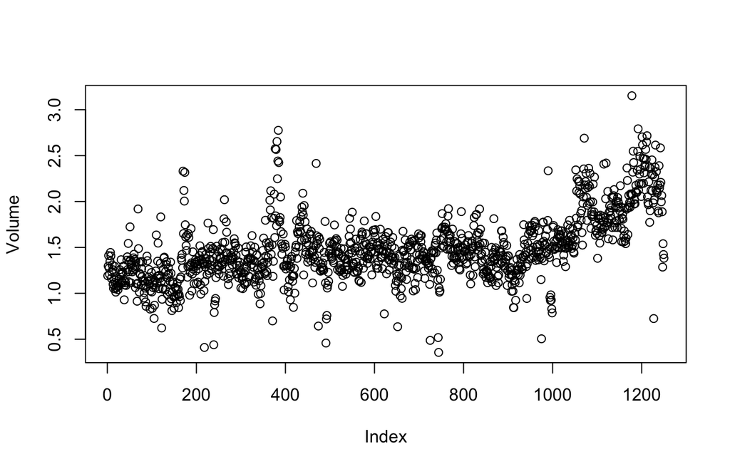

```r
attach(Smarket)
plot(Volume)
```

## 2 Logistic Regression

We fit a logistic regression model to predict `Direction` using the five lag variables and `Volume`.

```r
glm.fit=glm(Direction~Lag1+Lag2+Lag3+Lag4+Lag5+Volume,data=Smarket,family=binomial)
summary(glm.fit)
```

```
##
## Call:
## glm(formula = Direction ~ Lag1 + Lag2 + Lag3 + Lag4 + Lag5 +
##     Volume, family = binomial, data = Smarket)
##
## Coefficients:
##              Estimate Std. Error z value Pr(>|z|)
## (Intercept) -0.126000   0.240736  -0.523    0.601
## Lag1        -0.073074   0.050167  -1.457    0.145
## Lag2        -0.042301   0.050086  -0.845    0.398
## Lag3         0.011085   0.049939   0.222    0.824
## Lag4         0.009359   0.049974   0.187    0.851
## Lag5         0.010313   0.049511   0.208    0.835
## Volume       0.135441   0.158360   0.855    0.392
##
## (Dispersion parameter for binomial family taken to be 1)
##
##     Null deviance: 1731.2  on 1249  degrees of freedom
## Residual deviance: 1727.6  on 1243  degrees of freedom
## AIC: 1741.6
##
## Number of Fisher Scoring iterations: 3
```

```r
coef(glm.fit)
```

```
##  (Intercept)         Lag1         Lag2         Lag3         Lag4         Lag5
## -0.126000257 -0.073073746 -0.042301344  0.011085108  0.009358938  0.010313068
##       Volume
##  0.135440659
```

```r
summary(glm.fit)$coef
```

```
##                 Estimate Std. Error    z value  Pr(>|z|)
## (Intercept) -0.126000257 0.24073574 -0.5233966 0.6006983
## Lag1        -0.073073746 0.05016739 -1.4565986 0.1452272
## Lag2        -0.042301344 0.05008605 -0.8445733 0.3983491
## Lag3         0.011085108 0.04993854  0.2219750 0.8243333
## Lag4         0.009358938 0.04997413  0.1872757 0.8514445
## Lag5         0.010313068 0.04951146  0.2082966 0.8349974
## Volume       0.135440659 0.15835970  0.8552723 0.3924004
```

We compute predicted probabilities, convert them into class labels, and produce a confusion matrix along with the overall accuracy.

```r
glm.probs=predict(glm.fit,type="response")
glm.probs[1:10]
```

```
##         1         2         3         4         5         6         7         8
## 0.5070841 0.4814679 0.4811388 0.5152224 0.5107812 0.5069565 0.4926509 0.5092292
##         9        10
## 0.5176135 0.4888378
```

```r
contrasts(Direction)
```

```
##      Up
## Down  0
## Up    1
```

```r
glm.pred=rep("Down",1250)
glm.pred[glm.probs>.5]="Up"
table(glm.pred,Direction)
```

```
##         Direction
## glm.pred Down  Up
##     Down  145 141
##     Up    457 507
```

```r
(507+145)/1250
```

```
## [1] 0.5216
```

```r
mean(glm.pred==Direction)
```

```
## [1] 0.5216
```

## 3 Separate the Data into Training and Test

Next, we create a training set consisting of observations before 2005, and a test set (`Smarket.2005`) consisting of the 2005 observations, then refit the logistic regression on the training set only. This type of data split is especially suitable for *time series* data, i.e., data observed over time, as simple cross validation (or split-sample validation) does not make much sense in this context.

```r
train=(Year<2005)
Smarket.2005=Smarket[!train,]
dim(Smarket.2005)
```

```
## [1] 252   9
```

```r
Direction.2005=Direction[!train]
glm.fit=glm(Direction~Lag1+Lag2+Lag3+Lag4+Lag5+Volume,data=Smarket,family=binomial,subset=train)
glm.probs=predict(glm.fit,Smarket.2005,type="response")
glm.pred=rep("Down",252)
glm.pred[glm.probs>.5]="Up"
table(glm.pred,Direction.2005)
```

```
##         Direction.2005
## glm.pred Down Up
##     Down   77 97
##     Up     34 44
```

```r
mean(glm.pred==Direction.2005)
```

```
## [1] 0.4801587
```

```r
mean(glm.pred!=Direction.2005)
```

```
## [1] 0.5198413
```

We refit using only `Lag1` and `Lag2`, the variables that seemed to have the most predictive power, and evaluate on the test set. We also predict the probability of a market increase for two hypothetical days.

```r
glm.fit=glm(Direction~Lag1+Lag2,data=Smarket,family=binomial,subset=train)
glm.probs=predict(glm.fit,Smarket.2005,type="response")
glm.pred=rep("Down",252)
glm.pred[glm.probs>.5]="Up"
table(glm.pred,Direction.2005)
```

```
##         Direction.2005
## glm.pred Down  Up
##     Down   35  35
##     Up     76 106
```

```r
mean(glm.pred==Direction.2005)
```

```
## [1] 0.5595238
```

```r
106/(106+76)
```

```
## [1] 0.5824176
```

```r
predict(glm.fit,newdata=data.frame(Lag1=c(1.2,1.5),Lag2=c(1.1,-0.8)),type="response")
```

```
##         1         2
## 0.4791462 0.4960939
```

## 4 Penalized Logistic Regression

We set up the predictor matrix and response vector for use with `glmnet`.

```r
x = as.matrix(Smarket[1:1250, c(2:7)])
y = as.factor(Smarket[1:1250, 9])
```

### 4.1 Ridge

We fit a ridge-penalized logistic regression over a grid of lambda values, use cross-validation to select lambda, and evaluate the resulting model on the test set.

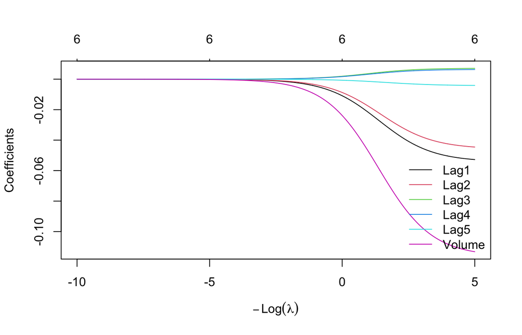

```r
glm.ridge=glmnet(x[train,],y[train],family="binomial",alpha=0,lambda=exp(seq(-5,10,0.01)))
plot(glm.ridge,col=c(1:8), xvar="lambda")
legend('bottomright',colnames(x),lty=1,col=c(1:8),bty='n')
```

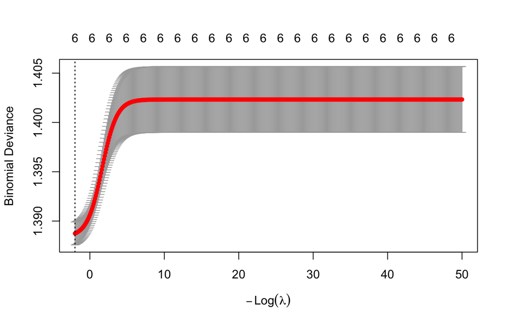

```r
cv.ridge=cv.glmnet(x[train,],y[train],family="binomial",alpha=0,lambda=exp(seq(-50,2,0.1)))
plot(cv.ridge)
```

```r
lambda.min=cv.ridge$lambda.min
ridge.probs=predict(glm.ridge,s=lambda.min,type="response",newx=x[!train,])
ridge.pred=rep("Down",252)
ridge.pred[ridge.probs>.5]="Up"
table(ridge.pred,Direction.2005)
```

```
##           Direction.2005
## ridge.pred Down  Up
##         Up  111 141
```

```r
mean(ridge.pred==Direction.2005)
```

```
## [1] 0.5595238
```

### 4.2 Lasso

We repeat the process using a lasso penalty instead. Note that we only need to change `alpha=0` in ridge to `alpha=1`. Everything else is the same.

[figure not shown]

```r
glm.lasso=glmnet(x[train,],y[train],family="binomial",alpha=1)
plot(glm.lasso,col=c(1:8))
legend('bottomleft',colnames(x),lty=1,col=c(1:8),bty='n')
```

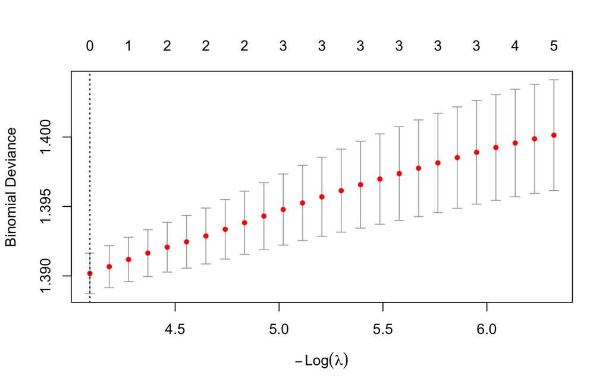

```r
cv.lasso=cv.glmnet(x[train,],y[train],family="binomial",alpha=1)
plot(cv.lasso)
```

```r
lambda.min=cv.lasso$lambda.min
lasso.probs=predict(glm.lasso,s=lambda.min,type="response",newx=x[!train,])
lasso.pred=rep("Down",252)
lasso.pred[lasso.probs>.5]="Up"
table(lasso.pred,Direction.2005)
```

```
##           Direction.2005
## lasso.pred Down  Up
##         Up  111 141
```

```r
mean(lasso.pred==Direction.2005)
```

```
## [1] 0.5595238
```

```r
predict(glm.lasso,s=lambda.min,type="coefficients",newx=x[!train,])
```

```
## 7 x 1 sparse Matrix of class "dgCMatrix"
##             s=0.01674372
## (Intercept)   0.03206688
## Lag1          .
## Lag2          .
## Lag3          .
## Lag4          .
## Lag5          .
## Volume        .
```

### 4.3 Other Choices of Lambda

One nice feature of the `glmnet` package is that it gives you a range of models, so you don’t have to refit the model every time you want to try a different tuning parameter `lambda` – you simply use the predict function and get the results for that value of `lambda`.

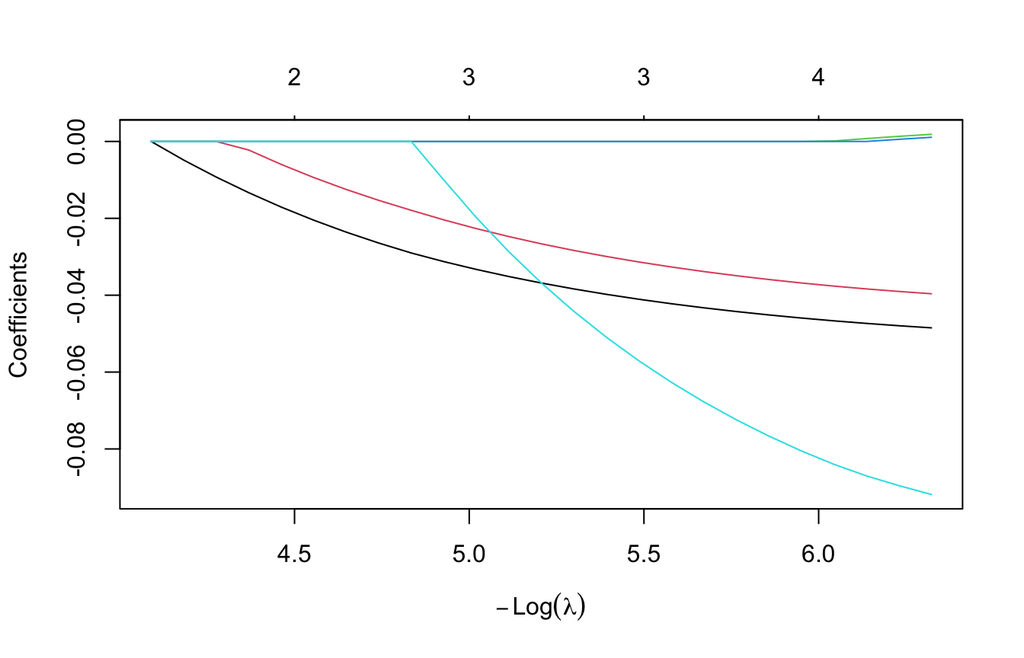

```r
plot(glm.lasso,col=c(1:8),xvar="lambda")
```

```r
lasso.probs=predict(glm.lasso,s=exp(-5),type="response",newx=x[!train,])
lasso.pred=rep("Down",252)
lasso.pred[lasso.probs>.5]="Up"
table(lasso.pred,Direction.2005)
```

```
##           Direction.2005
## lasso.pred Down  Up
##       Down   29  25
##       Up     82 116
```

```r
mean(lasso.pred==Direction.2005)
```

```
## [1] 0.5753968
```

## 5 K-Nearest Neighbors

Instead of the parametric approach used in logistic regression, we can use a fully nonparametric classification model based on K-nearest neighbors (KNN). In R, we can do this by using the `knn()` function.

Given its nonparametric nature, KNN cannot be fit with a large number of covariates, and is only applicable to small number of covariates, so here we use `Lag1` and `Lag2` and try different values of neighborhood size, `k`.

```r
library(class)
train.X=cbind(Lag1,Lag2)[train,]
test.X=cbind(Lag1,Lag2)[!train,]
train.Direction=Direction[train]
set.seed(1)
knn.pred=knn(train.X,test.X,train.Direction,k=1)
table(knn.pred,Direction.2005)
```

```
##         Direction.2005
## knn.pred Down Up
##     Down   43 58
##     Up     68 83
```

```r
(83+43)/252
```

```
## [1] 0.5
```

```r
knn.pred=knn(train.X,test.X,train.Direction,k=3)
table(knn.pred,Direction.2005)
```

```
##         Direction.2005
## knn.pred Down Up
##     Down   48 54
##     Up     63 87
```

```r
mean(knn.pred==Direction.2005)
```

```
## [1] 0.5357143
```

## 6 Another Example: Classification with the Heart Data

We load the `Heart` data set, available on GitHub, and explore it.

*Note: `Heart.rda` must be present in the working directory when knitting.*

```r
load("Heart.rda")
attach(Heart)

names(Heart)
```

```
##  [1] "age"      "sex"      "cp"       "trestbps" "chol"     "fbs"
##  [7] "restecg"  "thalach"  "exang"    "oldpeak"  "slope"    "ca"
## [13] "thal"     "HD"
```

```r
dim(Heart)
```

```
## [1] 297  14
```

```r
summary(Heart)
```

```
##       age             sex               cp           trestbps
##  Min.   :29.00   Min.   :0.0000   Min.   :1.000   Min.   : 94.0
##  1st Qu.:48.00   1st Qu.:0.0000   1st Qu.:3.000   1st Qu.:120.0
##  Median :56.00   Median :1.0000   Median :3.000   Median :130.0
##  Mean   :54.54   Mean   :0.6768   Mean   :3.158   Mean   :131.7
##  3rd Qu.:61.00   3rd Qu.:1.0000   3rd Qu.:4.000   3rd Qu.:140.0
##  Max.   :77.00   Max.   :1.0000   Max.   :4.000   Max.   :200.0
##       chol            fbs            restecg          thalach
##  Min.   :126.0   Min.   :0.0000   Min.   :0.0000   Min.   : 71.0
##  1st Qu.:211.0   1st Qu.:0.0000   1st Qu.:0.0000   1st Qu.:133.0
##  Median :243.0   Median :0.0000   Median :1.0000   Median :153.0
##  Mean   :247.4   Mean   :0.1448   Mean   :0.9966   Mean   :149.6
##  3rd Qu.:276.0   3rd Qu.:0.0000   3rd Qu.:2.0000   3rd Qu.:166.0
##  Max.   :564.0   Max.   :1.0000   Max.   :2.0000   Max.   :202.0
##      exang           oldpeak          slope             ca
##  Min.   :0.0000   Min.   :0.000   Min.   :1.000   Min.   :0.0000
##  1st Qu.:0.0000   1st Qu.:0.000   1st Qu.:1.000   1st Qu.:0.0000
##  Median :0.0000   Median :0.800   Median :2.000   Median :0.0000
##  Mean   :0.3266   Mean   :1.056   Mean   :1.603   Mean   :0.6768
##  3rd Qu.:1.0000   3rd Qu.:1.600   3rd Qu.:2.000   3rd Qu.:1.0000
##  Max.   :1.0000   Max.   :6.200   Max.   :3.000   Max.   :3.0000
##       thal             HD
##  Min.   :3.000   Min.   :0.0000
##  1st Qu.:3.000   1st Qu.:0.0000
##  Median :3.000   Median :0.0000
##  Mean   :4.731   Mean   :0.4613
##  3rd Qu.:7.000   3rd Qu.:1.0000
##  Max.   :7.000   Max.   :1.0000
```

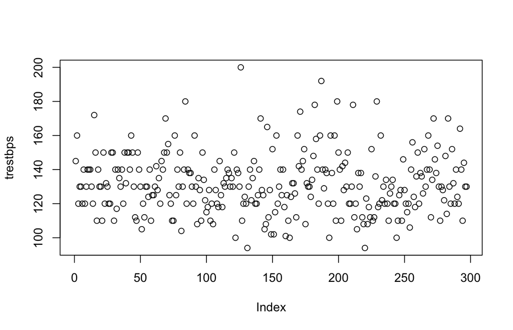

```r
plot(trestbps)
```

## 7 Separate the Data into Training and Test

```r
set.seed(1)
train=sample(1:nrow(Heart), 197)
trndat=Heart[train,]
tstdat=Heart[-train,]
dim(trndat)
```

```
## [1] 197  14
```

```r
dim(tstdat)
```

```
## [1] 100  14
```

## 8 Logistic Regression

We fit a logistic regression model to predict heart disease (`HD`) using all predictors, and evaluate it on the test set.

```r
HD.tst=HD[-train]
glm.fit=glm(HD~.,data=Heart,family=binomial,subset=train)
glm.probs=predict(glm.fit,tstdat,type="response")
glm.pred=numeric(100)
glm.pred[glm.probs>.5]=1
table(glm.pred,HD.tst)
```

```
##         HD.tst
## glm.pred  0  1
##        0 46 12
##        1  7 35
```

```r
mean(glm.pred==HD.tst)
```

```
## [1] 0.81
```

## 9 Penalized Logistic Regression

```r
n=nrow(Heart)
x=as.matrix(Heart[1:n,1:13])
y=as.factor(Heart[1:n,14])
```

### 9.1 Ridge

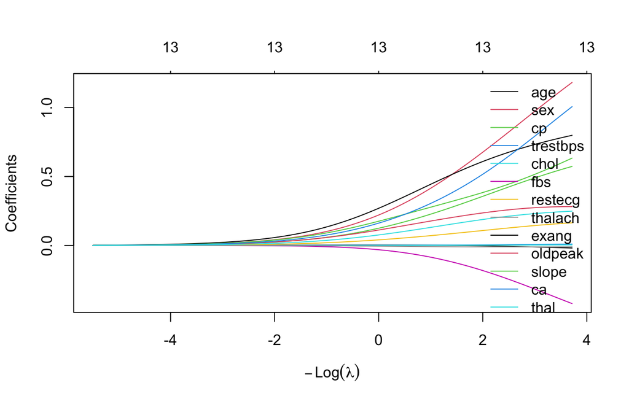

```r
glm.ridge=glmnet(x[train,],y[train],family="binomial",alpha=0)
plot(glm.ridge,col=c(1:8), xvar="lambda")
legend('topright',colnames(x),lty=1,col=c(1:8),bty='n')
```

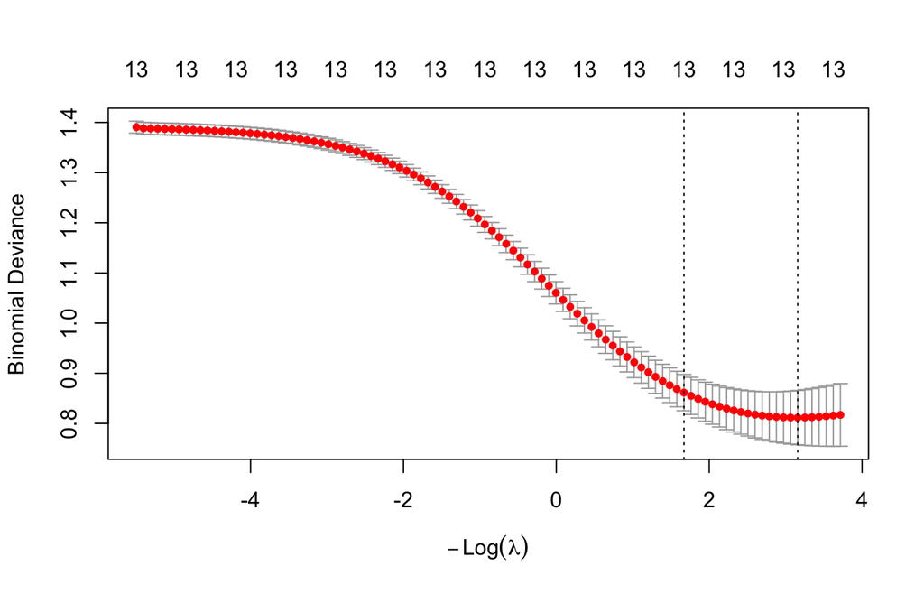

```r
cv.ridge=cv.glmnet(x[train,],y[train],family="binomial",alpha=0)
plot(cv.ridge)
```

```r
lambda.min=cv.ridge$lambda.min
ridge.probs=predict(glm.ridge,s=lambda.min,type="response",newx=x[-train,])
ridge.pred=rep(0,100)
ridge.pred[ridge.probs>.5]=1
table(ridge.pred,HD.tst)
```

```
##           HD.tst
## ridge.pred  0  1
##          0 46  9
##          1  7 38
```

```r
mean(ridge.pred==HD.tst)
```

```
## [1] 0.84
```

### 9.2 Lasso

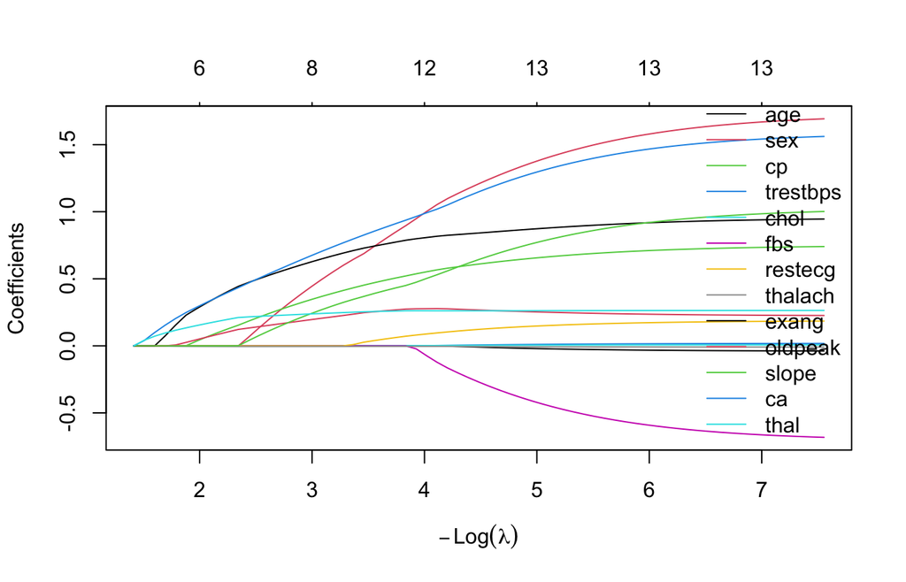

```r
glm.lasso=glmnet(x[train,],y[train],family="binomial",alpha=1)
plot(glm.lasso,col=c(1:8), xvar="lambda")
legend('bottomright',colnames(x),lty=1,col=c(1:8),bty='n')
```

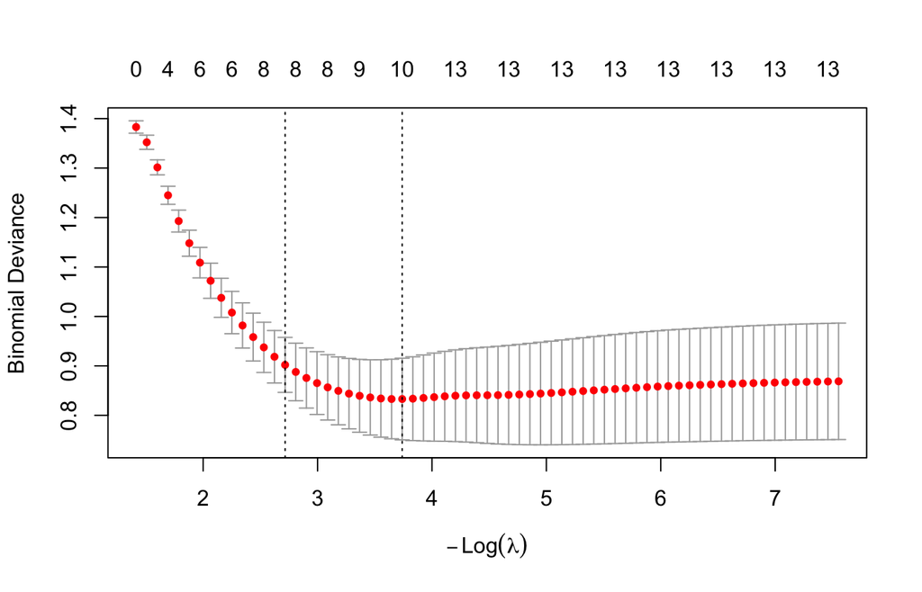

```r
cv.lasso=cv.glmnet(x[train,],y[train],family="binomial",alpha=1)
plot(cv.lasso)
```

```r
lambda.min=cv.lasso$lambda.min
lasso.probs=predict(glm.lasso,s=lambda.min,type="response",newx=x[-train,])
lasso.pred=rep(0,100)
lasso.pred[ridge.probs>.5]=1
table(lasso.pred,HD.tst)
```

```
##           HD.tst
## lasso.pred  0  1
##          0 46  9
##          1  7 38
```

```r
mean(lasso.pred==HD.tst)
```

```
## [1] 0.84
```

## 10 K-Nearest Neighbors

```r
library(class)
train.X=cbind(ca,thal)[train,1:2]
test.X=cbind(ca,thal)[-train,1:2]
HD.trn=HD[train]
set.seed(1)
knn.pred=knn(train.X,test.X,as.factor(HD.trn),k=1)
table(knn.pred,HD.tst)
```

```
##         HD.tst
## knn.pred  0  1
##        0 45 11
##        1  8 36
```

```r
mean(knn.pred==HD.tst)
```

```
## [1] 0.81
```

```r
knn.pred=knn(train.X,test.X,HD.trn,k=10)
table(knn.pred,HD.tst)
```

```
##         HD.tst
## knn.pred  0  1
##        0 43 11
##        1 10 36
```

```r
mean(knn.pred==HD.tst)
```

```
## [1] 0.79
```

## 11 SVM

We fit a support vector machine with a radial kernel to the Heart data, then use `tune.svm()` to select the cost and gamma parameters via cross-validation.

```r
dat=Heart
dat$HD=as.factor(HD)
svmfit=svm(HD~.,data=dat[train,],kernel="radial",gamma=1,cost=1)
svm.pred=predict(svmfit,newdata=dat[-train,-14])
table(true=dat[-train,14], pred=svm.pred)
```

```
##     pred
## true  0  1
##    0 53  0
##    1 42  5
```

```r
mean(dat[-train,14]==svm.pred)
```

```
## [1] 0.58
```

```r
set.seed(1)
tune.out=tune.svm(x=dat[train,-14],y=dat[train,14],kernel="radial",
                  cost=c(0.1,1,10,100,1000),gamma=c(0.5,1,2,3,4))
summary(tune.out)
```

```
##
## Parameter tuning of 'svm':
##
## - sampling method: 10-fold cross validation
##
## - best parameters:
##  gamma cost
##    0.5    1
##
## - best performance: 0.2786842
##
## - Detailed performance results:
##    gamma  cost     error dispersion
## 1    0.5 1e-01 0.4563158 0.09333102
## 2    1.0 1e-01 0.4563158 0.09333102
## 3    2.0 1e-01 0.4563158 0.09333102
## 4    3.0 1e-01 0.4563158 0.09333102
## 5    4.0 1e-01 0.4563158 0.09333102
## 6    0.5 1e+00 0.2786842 0.08482461
## 7    1.0 1e+00 0.4160526 0.08753885
## 8    2.0 1e+00 0.4463158 0.09046748
## 9    3.0 1e+00 0.4563158 0.09333102
## 10   4.0 1e+00 0.4563158 0.09333102
## 11   0.5 1e+01 0.2797368 0.10840381
## 12   1.0 1e+01 0.4110526 0.10155607
## 13   2.0 1e+01 0.4263158 0.09320562
## 14   3.0 1e+01 0.4463158 0.09046748
## 15   4.0 1e+01 0.4563158 0.09333102
## 16   0.5 1e+02 0.2797368 0.10840381
## 17   1.0 1e+02 0.4110526 0.10155607
## 18   2.0 1e+02 0.4263158 0.09320562
## 19   3.0 1e+02 0.4463158 0.09046748
## 20   4.0 1e+02 0.4563158 0.09333102
## 21   0.5 1e+03 0.2797368 0.10840381
## 22   1.0 1e+03 0.4110526 0.10155607
## 23   2.0 1e+03 0.4263158 0.09320562
## 24   3.0 1e+03 0.4463158 0.09046748
## 25   4.0 1e+03 0.4563158 0.09333102
```

```r
svmfit=svm(HD~.,data=dat[train,],kernel="radial",gamma=tune.out$best.parameters$gamma,cost=tune.out$best.parameters$cost)
svm.pred=predict(svmfit,newdata=dat[-train,-14])
table(true=dat[-train,14], pred=svm.pred)
```

```
##     pred
## true  0  1
##    0 42 11
##    1  8 39
```

```r
mean(dat[-train,14]==svm.pred)
```

```
## [1] 0.81
```

## 12 ROC Curves

We define a helper function to plot ROC curves from fitted decision values, and compare an “optimal” versus a more flexible SVM fit on the training and test data.

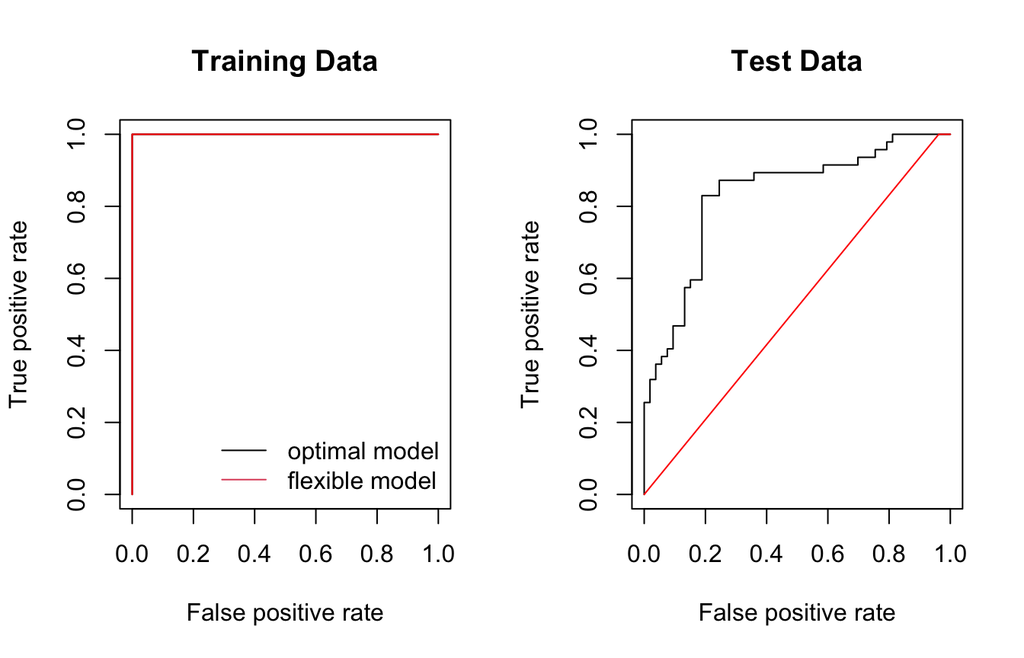

```r
rocplot=function(pred, truth, ...){
  predob = prediction(pred, truth)
  perf = performance(predob, "tpr", "fpr")
  plot(perf,...)}

svmfit.opt=svm(HD~., data=dat[train,], kernel="radial", gamma=2, cost=1, decision.values=T)
fitted=attributes(predict(svmfit.opt,dat[train,],decision.values=TRUE))$decision.values
par(mfrow=c(1,2))
rocplot(fitted,dat[train,"HD"],main="Training Data")
svmfit.flex=svm(HD~., data=dat[train,], kernel="radial",gamma=50, cost=1, decision.values=T)
fitted=attributes(predict(svmfit.flex,dat[train,],decision.values=T))$decision.values
rocplot(fitted,dat[train,"HD"],add=T,col="red")
legend('bottomright',c('optimal model','flexible model'),lty=1,col=c(1,2),bty='n')
fitted=attributes(predict(svmfit.opt,dat[-train,],decision.values=T))$decision.values
rocplot(fitted,dat[-train,"HD"],main="Test Data")
fitted=attributes(predict(svmfit.flex,dat[-train,],decision.values=T))$decision.values
rocplot(fitted,dat[-train,"HD"],add=T,col="red")
```